# Behaviours

# Plotting Distance_moved x Sex

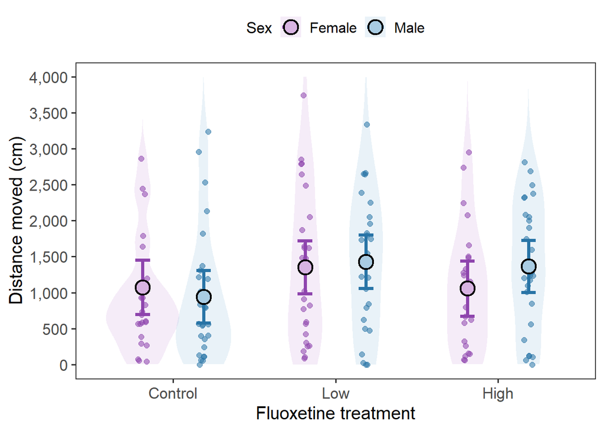

```r
# Prepare labels
data <- data %>%
  mutate(
    treatment = factor(treatment, levels = c("control", "low", "high")),
    sex = factor(sex, levels = c("female", "male")),
    treatment_plot = factor(
      treatment,
      levels = c("control", "low", "high"),
      labels = c("Control", "Low", "High")
    ),
    sex_plot = factor(
      sex,
      levels = c("female", "male"),
      labels = c("Female", "Male")
    )
  )

# Estimated marginal means for treatment × sex interaction
emm_distance_int_df <- as.data.frame(
  emmeans(
    m_distance_int,
    ~ sex | treatment
  )
)

cn <- names(emm_distance_int_df)

mean_col  <- dplyr::first(cn[cn %in% c("response", "rate", "emmean")])

lower_col <- dplyr::first(
  cn[grepl("^lower\\.CL$|^asymp\\.LCL$|^LCL$|^lower$", cn)]
)

upper_col <- dplyr::first(
  cn[grepl("^upper\\.CL$|^asymp\\.UCL$|^UCL$|^upper$", cn)]
)

emm_distance_int_df <- emm_distance_int_df %>%
  mutate(
    treatment = factor(treatment, levels = c("control", "low", "high")),
    sex = factor(sex, levels = c("female", "male")),
    treatment_plot = factor(
      treatment,
      levels = c("control", "low", "high"),
      labels = c("Control", "Low", "High")
    ),
    sex_plot = factor(
      sex,
      levels = c("female", "male"),
      labels = c("Female", "Male")
    )
  ) %>%
  rename(
    mean  = !!mean_col,
    lower = !!lower_col,
    upper = !!upper_col
  )

# Colour palettes for sex

sex_pastel_cols <- c(
  "Female" = "#D8B4E2",
  "Male"   = "#A9CCE3"
)

sex_dark_cols <- c(
  "Female" = "#8E44AD",
  "Male"   = "#2874A6"
)


# Plot: sex side by side within treatment
pd <- position_dodge(width = 0.75)

pj <- position_jitterdodge(
  jitter.width = 0.12,
  dodge.width = 0.75
)

p_distance_int_side <- ggplot() +

  geom_violin(
    data = data,
    aes(
      x = treatment_plot,
      y = distance_cm,
      fill = sex_plot,
      group = interaction(treatment_plot, sex_plot)
    ),
    position = pd,
    trim = FALSE,
    alpha = 0.25,
    colour = NA,
    linewidth = 0
  ) +

  geom_point(
    data = data,
    aes(
      x = treatment_plot,
      y = distance_cm,
      colour = sex_plot,
      group = sex_plot
    ),
    position = pj,
    alpha = 0.55,
    size = 2
  ) +

  geom_errorbar(
    data = emm_distance_int_df,
    aes(
      x = treatment_plot,
      ymin = lower,
      ymax = upper,
      colour = sex_plot,
      group = sex_plot
    ),
    position = pd,
    width = 0.18,
    linewidth = 1.3
  ) +

  geom_point(
    data = emm_distance_int_df,
    aes(
      x = treatment_plot,
      y = mean,
      fill = sex_plot,
      group = sex_plot
    ),
    position = pd,
    shape = 21,
    size = 5,
    stroke = 1.2,
    colour = "black"
  ) +

  scale_colour_manual(values = sex_dark_cols) +
  scale_fill_manual(values = sex_pastel_cols) +

  scale_y_continuous(
    limits = c(0, 4000),
    breaks = seq(0, 4000, by = 500),
    labels = scales::comma
  ) +

  labs(
    x = "Fluoxetine treatment",
    y = "Distance moved (cm)",
    fill = "Sex",
    colour = "Sex"
  ) +

  theme_bw(base_size = 14) +

  theme(
    panel.grid = element_blank(),
    legend.position = "top",
    legend.title = element_text(size = 13),
    legend.text = element_text(size = 12),
    axis.title = element_text(size = 15),
    axis.text = element_text(size = 13)
  )

print(p_distance_int_side)
```

```r
# Save
ggsave(
  filename = here("figures", "distance_moved_treatment_sex_side_by_side.pdf"),
  plot = p_distance_int_side,
  width = 7,
  height = 5
)
ggsave(
  filename = here("figures", "distance_moved_treatment_sex_side_by_side.jpg"),
  plot = p_distance_int_side,
  width = 7,
  height = 5,
  dpi = 600
)
```

## Distance_moved

## Main effects model

```r
# Linear model
m_distance <- lm(
  distance_cm ~ treatment + sex + body_mass_sc,
  data = data
)

summary(m_distance)
```

```
##
## Call:
## lm(formula = distance_cm ~ treatment + sex + body_mass_sc, data = data)
##
## Residuals:
##     Min      1Q  Median      3Q     Max
## -1411.7  -751.5  -154.0   567.3  3515.0
##
## Coefficients:
##               Estimate Std. Error t value Pr(>|t|)
## (Intercept)     961.14     154.47   6.222 4.66e-09 ***
## treatmentlow    387.47     185.08   2.093    0.038 *
## treatmenthigh   213.16     185.94   1.146    0.253
## sexmale          85.69     158.13   0.542    0.589
## body_mass_sc    -29.39      79.13  -0.371    0.711
## ---
## Signif. codes:  0 '***' 0.001 '**' 0.01 '*' 0.05 '.' 0.1 ' ' 1
##
## Residual standard error: 943.1 on 150 degrees of freedom
##   (1 observation deleted due to missingness)
## Multiple R-squared:  0.03022,    Adjusted R-squared:  0.004364
## F-statistic: 1.169 on 4 and 150 DF,  p-value: 0.3269
```

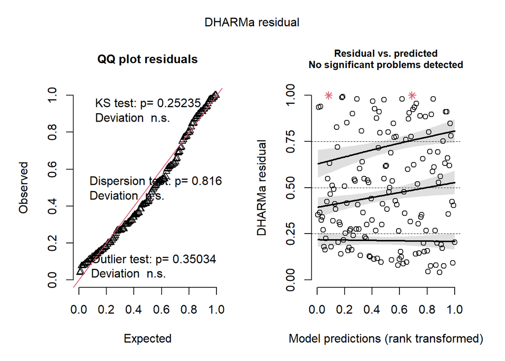

```r
# Diagnosis
res_m1_distance_moved <- simulateResiduals(m_distance)
plot(res_m1_distance_moved)
```

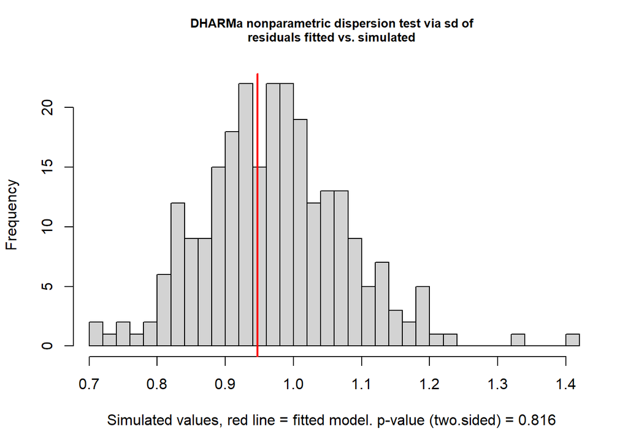

```
##
##  DHARMa nonparametric dispersion test via sd of residuals fitted vs.
##  simulated
##
## data:  simulationOutput
## dispersion = 0.97399, p-value = 0.816
## alternative hypothesis: two.sided
```

```r
testDispersion(res_m1_distance_moved)
```

```r
testZeroInflation(res_m1_distance_moved)
```

```
##
##  DHARMa zero-inflation test via comparison to expected zeros with
##  simulation under H0 = fitted model
##
## data:  simulationOutput
## ratioObsSim = NaN, p-value = 1
## alternative hypothesis: two.sided
```

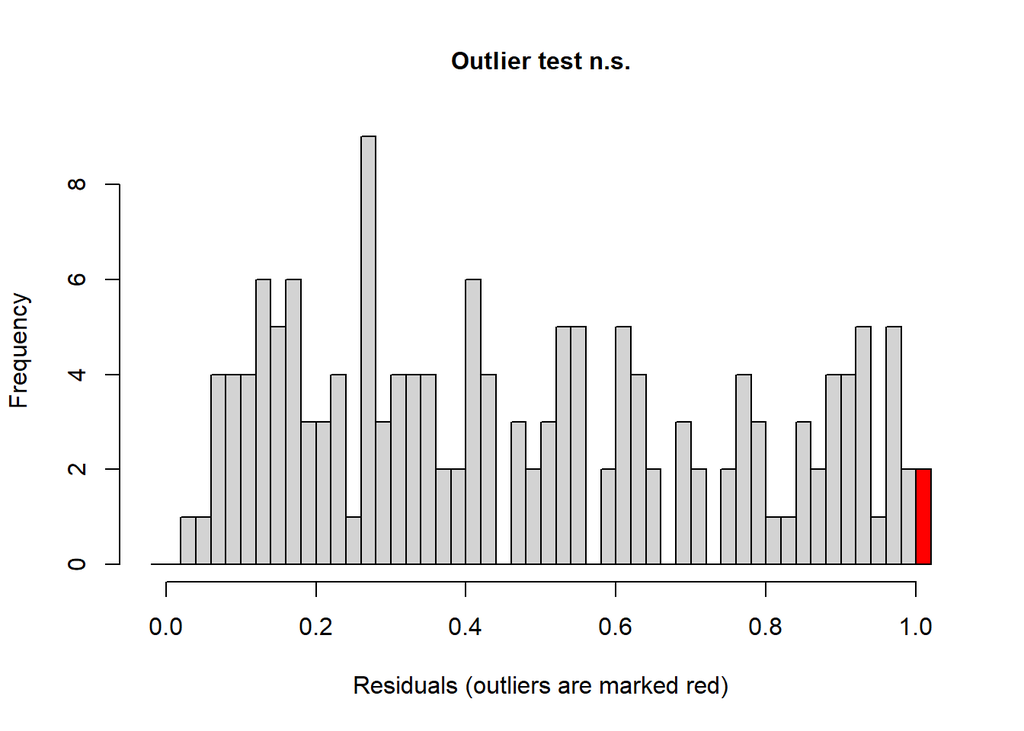

```
##
##  DHARMa outlier test based on exact binomial test with approximate
##  expectations
##
## data:  res_m1_distance_moved
## outliers at both margin(s) = 2, observations = 155, p-value = 0.3503
## alternative hypothesis: true probability of success is not equal to 0.007968127
## 95 percent confidence interval:
##  0.001566478 0.045831890
## sample estimates:
## frequency of outliers (expected: 0.00796812749003984 )
##                                             0.01290323
```

```r
testOutliers(res_m1_distance_moved)
```

```r
#Anova of the model
Anova(m_distance, type = "II")
```

```
## Anova Table (Type II tests)
##
## Response: distance_cm
##                 Sum Sq  Df F value Pr(>F)
## treatment      3912025   2  2.1991 0.1145
## sex             261163   1  0.2936 0.5887
## body_mass_sc    122739   1  0.1380 0.7108
## Residuals    133421186 150
```

```r
emmeans(m_distance, pairwise ~ treatment, adjust = "tukey")
```

```
## $emmeans
##  treatment emmean  SE  df lower.CL upper.CL
##  control     1004 131 150      746     1263
##  low         1392 131 150     1133     1650
##  high        1217 132 150      956     1479
##
## Results are averaged over the levels of: sex
## Confidence level used: 0.95
##
## $contrasts
##  contrast       estimate  SE  df t.ratio p.value
##  control - low      -387 185 150  -2.093  0.0946
##  control - high     -213 186 150  -1.146  0.4872
##  low - high          174 186 150   0.936  0.6185
##
## Results are averaged over the levels of: sex
## P value adjustment: tukey method for comparing a family of 3 estimates
```

```r
anova(m_distance, m_distance_int)
```

```
## Analysis of Variance Table
##
## Model 1: distance_cm ~ treatment + sex + body_mass_sc
## Model 2: distance_cm ~ treatment * sex + body_mass_sc
##   Res.Df       RSS Df Sum of Sq      F Pr(>F)
## 1    150 133421186
## 2    148 132193525  2   1227661 0.6872 0.5046
```

## Plotting

## Behaviour: Distance_moved

```r
#---------------------------------------------------------
# 1) Ensure treatment order
#---------------------------------------------------------

data$treatment <- factor(
  data$treatment,
  levels = c("control", "low", "high")
)

# Labels for plotting
data$treatment_plot <- factor(
  data$treatment,
  levels = c("control", "low", "high"),
  labels = c("Control", "Low", "High")
)

#---------------------------------------------------------
# 2) Fit final model
#---------------------------------------------------------

m_distance <- lm(
  distance_cm ~ treatment + sex + body_mass,
  data = data
)

summary(m_distance)
```

```
##
## Call:
## lm(formula = distance_cm ~ treatment + sex + body_mass, data = data)
##
## Residuals:
##     Min      1Q  Median      3Q     Max
## -1411.7  -751.5  -154.0   567.3  3515.0
##
## Coefficients:
##               Estimate Std. Error t value Pr(>|t|)
## (Intercept)    1056.03     277.56   3.805 0.000206 ***
## treatmentlow    387.47     185.08   2.093 0.037989 *
## treatmenthigh   213.16     185.94   1.146 0.253468
## sexmale          85.69     158.13   0.542 0.588717
## body_mass      -142.24     382.92  -0.371 0.710811
## ---
## Signif. codes:  0 '***' 0.001 '**' 0.01 '*' 0.05 '.' 0.1 ' ' 1
##
## Residual standard error: 943.1 on 150 degrees of freedom
##   (1 observation deleted due to missingness)
## Multiple R-squared:  0.03022,    Adjusted R-squared:  0.004364
## F-statistic: 1.169 on 4 and 150 DF,  p-value: 0.3269
```

```r
Anova(m_distance, type = "II")
```

```
## Anova Table (Type II tests)
##
## Response: distance_cm
##              Sum Sq  Df F value Pr(>F)
## treatment   3912025   2  2.1991 0.1145
## sex          261163   1  0.2936 0.5887
## body_mass    122739   1  0.1380 0.7108
## Residuals 133421186 150
```

```r
#---------------------------------------------------------
# 3) Estimated marginal means
#---------------------------------------------------------

emm_dist_df <- as.data.frame(
  emmeans(m_distance, ~ treatment)
)

print(emm_dist_df)
```

```
##  treatment   emmean       SE  df  lower.CL upper.CL
##  control   1004.041 130.8237 150  745.5459 1262.536
##  low       1391.507 130.8825 150 1132.8951 1650.118
##  high      1217.203 132.2857 150  955.8186 1478.587
##
## Results are averaged over the levels of: sex
## Confidence level used: 0.95
```

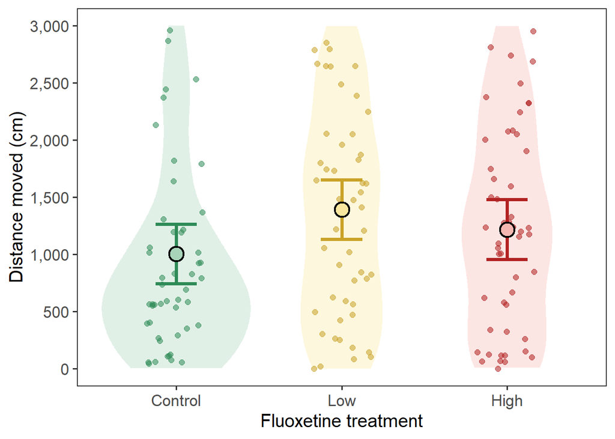

```r
#---------------------------------------------------------
# 4) Standardise column names
#---------------------------------------------------------

cn <- names(emm_dist_df)

mean_col  <- dplyr::first(cn[cn %in% c("response", "rate", "emmean")])

lower_col <- dplyr::first(
  cn[grepl("^lower\\.CL$|^asymp\\.LCL$|^LCL$|^lower$", cn)]
)

upper_col <- dplyr::first(
  cn[grepl("^upper\\.CL$|^asymp\\.UCL$|^UCL$|^upper$", cn)]
)

if (is.na(mean_col) | is.na(lower_col) | is.na(upper_col)) {
  stop("Could not identify CI columns.")
}

emm_dist_df <- emm_dist_df %>%
  mutate(
    treatment = factor(
      treatment,
      levels = c("control", "low", "high")
    ),
    treatment_plot = factor(
      treatment,
      levels = c("control", "low", "high"),
      labels = c("Control", "Low", "High")
    )
  ) %>%
  rename(
    mean  = !!mean_col,
    lower = !!lower_col,
    upper = !!upper_col
  )

#---------------------------------------------------------
# 5) Colour palette
#---------------------------------------------------------

pastel_cols <- c(
  "Control" = "#A8D5BA",
  "Low"     = "#F9E79F",
  "High"    = "#F5B7B1"
)

dark_cols <- c(
  "Control" = "#2E8B57",
  "Low"     = "#C9A227",
  "High"    = "#B22222"
)

#---------------------------------------------------------
# 6) Plot
#---------------------------------------------------------

p_distance <- ggplot() +

  geom_violin(
    data = data,
    aes(
      x = treatment_plot,
      y = distance_cm,
      fill = treatment_plot
    ),
    trim = FALSE,
    alpha = 0.35,
    colour = NA
  ) +

  geom_jitter(
    data = data,
    aes(
      x = treatment_plot,
      y = distance_cm,
      colour = treatment_plot
    ),
    width = 0.18,
    alpha = 0.55,
    size = 2
  ) +

  geom_errorbar(
    data = emm_dist_df,
    aes(
      x = treatment_plot,
      ymin = lower,
      ymax = upper,
      colour = treatment_plot
    ),
    width = 0.25,
    linewidth = 1.3
  ) +

  geom_point(
    data = emm_dist_df,
    aes(
      x = treatment_plot,
      y = mean,
      fill = treatment_plot
    ),
    shape = 21,
    size = 5,
    stroke = 1.2,
    colour = "black"
  ) +

  scale_colour_manual(values = dark_cols) +
  scale_fill_manual(values = pastel_cols) +

  scale_y_continuous(
    limits = c(0, 3000),
    breaks = seq(0, 3000, by = 500),
    labels = comma
  ) +

  labs(
    x = "Fluoxetine treatment",
    y = "Distance moved (cm)"
  ) +

  theme_bw(base_size = 14) +

  theme(
    panel.grid = element_blank(),
    legend.position = "none",
    plot.title = element_blank(),
    axis.title = element_text(size = 15),
    axis.text = element_text(size = 13)
  )

print(p_distance)
```

```r
#---------------------------------------------------------
# 7) Save
#---------------------------------------------------------

ggsave(here("figures", "distance_moved.pdf"), p_distance, width = 6, height = 5)
ggsave(here("figures", "distance_moved.jpg"), p_distance, width = 6, height = 5, dpi = 600)
```

## Time-freezing x sex:

## Time (in s) that fish was in open arena but not moving during the trials.

```r
# Interaction (full) model

m_freezing_int <- lm(
  freezing_s ~ treatment * sex + body_mass_sc,
  data = data
)

summary(m_freezing_int)
```

```
##
## Call:
## lm(formula = freezing_s ~ treatment * sex + body_mass_sc, data = data)
##
## Residuals:
##     Min      1Q  Median      3Q     Max
## -654.57 -132.33   15.68  148.56  300.11
##
## Coefficients:
##                       Estimate Std. Error t value Pr(>|t|)
## (Intercept)            908.889     40.075  22.680   <2e-16 ***
## treatmentlow            43.411     55.625   0.780   0.4364
## treatmenthigh            8.081     56.756   0.142   0.8870
## sexmale                134.830     56.050   2.406   0.0174 *
## body_mass_sc           -10.702     16.706  -0.641   0.5228
## treatmentlow:sexmale  -140.386     77.936  -1.801   0.0737 .
## treatmenthigh:sexmale -152.422     78.464  -1.943   0.0540 .
## ---
## Signif. codes:  0 '***' 0.001 '**' 0.01 '*' 0.05 '.' 0.1 ' ' 1
##
## Residual standard error: 198.6 on 148 degrees of freedom
##   (1 observation deleted due to missingness)
## Multiple R-squared:  0.0592, Adjusted R-squared:  0.02106
## F-statistic: 1.552 on 6 and 148 DF,  p-value: 0.1652
```

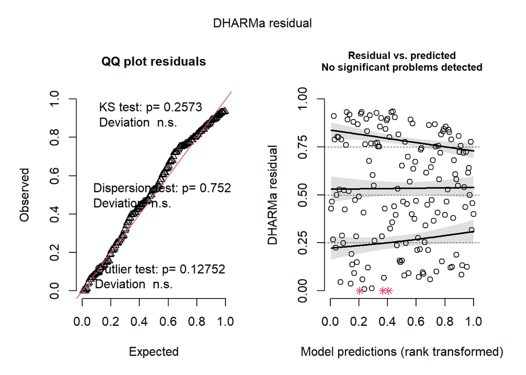

```r
#Diagnosis
res_m1_freezing_int <- simulateResiduals(m_freezing_int)
plot(res_m1_freezing_int)
```

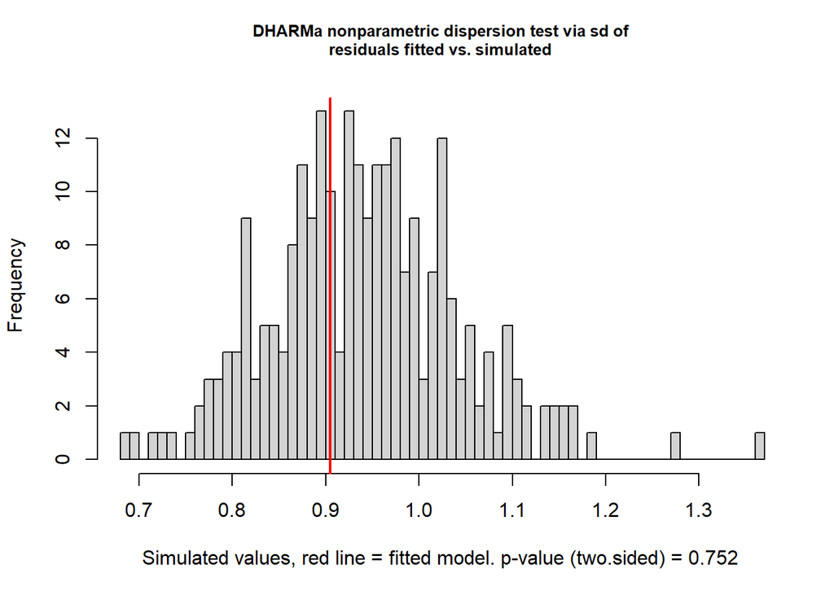

```
##
##  DHARMa nonparametric dispersion test via sd of residuals fitted vs.
##  simulated
##
## data:  simulationOutput
## dispersion = 0.961, p-value = 0.752
## alternative hypothesis: two.sided
```

```r
testDispersion(res_m1_freezing_int)
```

```r
testZeroInflation(res_m1_freezing_int)
```

```
##
##  DHARMa zero-inflation test via comparison to expected zeros with
##  simulation under H0 = fitted model
##
## data:  simulationOutput
## ratioObsSim = NaN, p-value = 1
## alternative hypothesis: two.sided
```

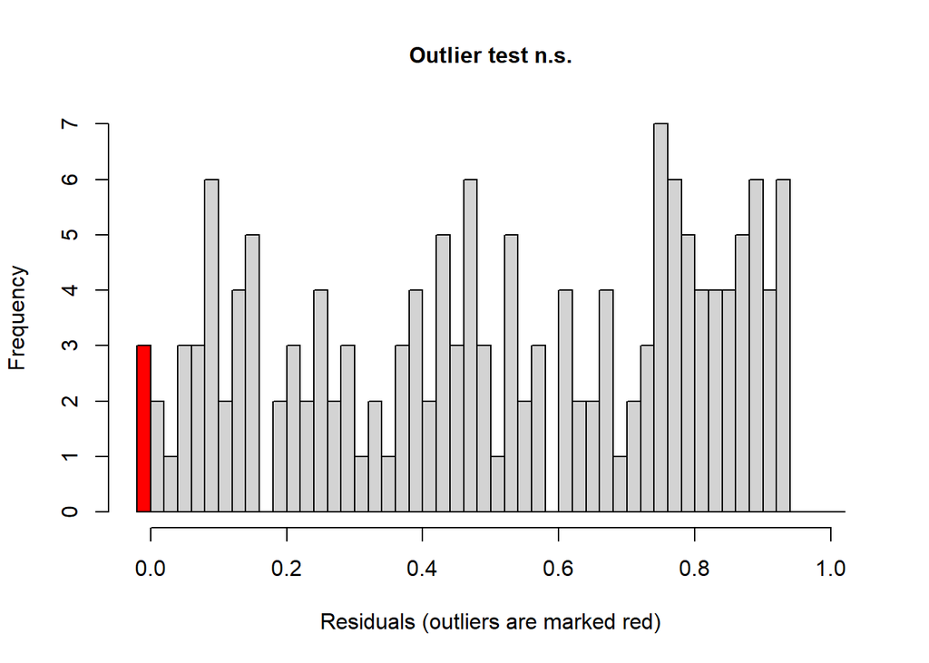

```
##
##  DHARMa outlier test based on exact binomial test with approximate
##  expectations
##
## data:  res_m1_freezing_int
## outliers at both margin(s) = 3, observations = 155, p-value = 0.1275
## alternative hypothesis: true probability of success is not equal to 0.007968127
## 95 percent confidence interval:
##  0.004009358 0.055519235
## sample estimates:
## frequency of outliers (expected: 0.00796812749003984 )
##                                             0.01935484
```

```r
testOutliers(res_m1_freezing_int)
```

```r
#Anova
Anova(m_freezing_int, type = "III")
```

```
## Anova Table (Type III tests)
##
## Response: freezing_s
##                 Sum Sq  Df  F value  Pr(>F)
## (Intercept)   20282755   1 514.3622 < 2e-16 ***
## treatment        27241   2   0.3454 0.70850
## sex             228185   1   5.7867 0.01738 *
## body_mass_sc     16183   1   0.4104 0.52276
## treatment:sex   185551   2   2.3527 0.09866 .
## Residuals      5836058 148
## ---
## Signif. codes:  0 '***' 0.001 '**' 0.01 '*' 0.05 '.' 0.1 ' ' 1
```

```r
emmeans(m_freezing_int, pairwise ~ treatment | sex, adjust = "tukey")
```

```
## $emmeans
## sex = female:
##  treatment emmean   SE  df lower.CL upper.CL
##  control      909 40.1 148      830      988
##  low          952 39.3 148      875     1030
##  high         917 40.8 148      836      998
##
## sex = male:
##  treatment emmean   SE  df lower.CL upper.CL
##  control     1044 38.5 148      968     1120
##  low          947 39.6 148      869     1025
##  high         899 38.3 148      824      975
##
## Confidence level used: 0.95
##
## $contrasts
## sex = female:
##  contrast       estimate   SE  df t.ratio p.value
##  control - low    -43.41 55.6 148  -0.780  0.7156
##  control - high    -8.08 56.8 148  -0.142  0.9889
##  low - high        35.33 56.2 148   0.629  0.8047
##
## sex = male:
##  contrast       estimate   SE  df t.ratio p.value
##  control - low     96.97 54.6 148   1.776  0.1812
##  control - high   144.34 54.1 148   2.667  0.0230
##  low - high        47.37 54.8 148   0.864  0.6636
##
## P value adjustment: tukey method for comparing a family of 3 estimates
```

```r
emmeans(m_freezing_int, pairwise ~ sex | treatment, adjust = "tukey")
```

```
## $emmeans
## treatment = control:
##  sex    emmean   SE  df lower.CL upper.CL
##  female    909 40.1 148      830      988
##  male     1044 38.5 148      968     1120
##
## treatment = low:
##  sex    emmean   SE  df lower.CL upper.CL
##  female    952 39.3 148      875     1030
##  male      947 39.6 148      869     1025
##
## treatment = high:
##  sex    emmean   SE  df lower.CL upper.CL
##  female    917 40.8 148      836      998
##  male      899 38.3 148      824      975
##
## Confidence level used: 0.95
##
## $contrasts
## treatment = control:
##  contrast      estimate   SE  df t.ratio p.value
##  female - male  -134.83 56.0 148  -2.406  0.0174
##
## treatment = low:
##  contrast      estimate   SE  df t.ratio p.value
##  female - male     5.56 56.3 148   0.099  0.9216
##
## treatment = high:
##  contrast      estimate   SE  df t.ratio p.value
##  female - male    17.59 56.1 148   0.314  0.7541
```

#Plottin time_freezing x sex

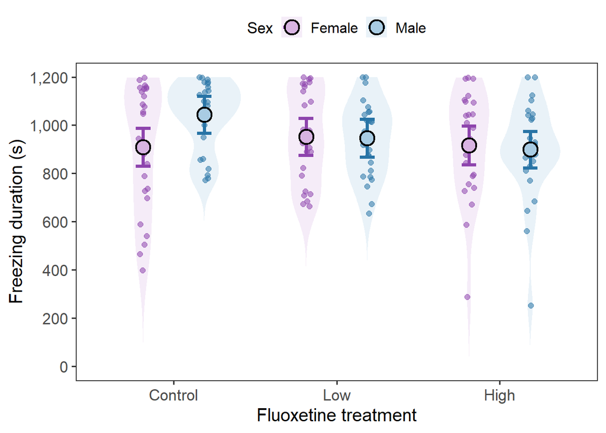

```r
#---------------------------------------------------------
# Prepare labels
#---------------------------------------------------------

data <- data %>%
  mutate(
    treatment = factor(treatment, levels = c("control", "low", "high")),
    sex = factor(sex, levels = c("female", "male")),
    treatment_plot = factor(
      treatment,
      levels = c("control", "low", "high"),
      labels = c("Control", "Low", "High")
    ),
    sex_plot = factor(
      sex,
      levels = c("female", "male"),
      labels = c("Female", "Male")
    )
  )

#---------------------------------------------------------
# Estimated marginal means for treatment × sex interaction
#---------------------------------------------------------

emm_freezing_int_df <- as.data.frame(
  emmeans(
    m_freezing_int,
    ~ sex | treatment
  )
)

cn <- names(emm_freezing_int_df)

mean_col  <- dplyr::first(cn[cn %in% c("response", "rate", "emmean")])

lower_col <- dplyr::first(
  cn[grepl("^lower\\.CL$|^asymp\\.LCL$|^LCL$|^lower$", cn)]
)

upper_col <- dplyr::first(
  cn[grepl("^upper\\.CL$|^asymp\\.UCL$|^UCL$|^upper$", cn)]
)

emm_freezing_int_df <- emm_freezing_int_df %>%
  mutate(
    treatment = factor(treatment, levels = c("control", "low", "high")),
    sex = factor(sex, levels = c("female", "male")),
    treatment_plot = factor(
      treatment,
      levels = c("control", "low", "high"),
      labels = c("Control", "Low", "High")
    ),
    sex_plot = factor(
      sex,
      levels = c("female", "male"),
      labels = c("Female", "Male")
    )
  ) %>%
  rename(
    mean  = !!mean_col,
    lower = !!lower_col,
    upper = !!upper_col
  )

#---------------------------------------------------------
# Colour palettes for sex
#---------------------------------------------------------

sex_pastel_cols <- c(
  "Female" = "#D8B4E2",
  "Male"   = "#A9CCE3"
)

sex_dark_cols <- c(
  "Female" = "#8E44AD",
  "Male"   = "#2874A6"
)

#---------------------------------------------------------
# Plot: sex side by side within treatment
#---------------------------------------------------------

pd <- position_dodge(width = 0.75)
pj <- position_jitterdodge(
  jitter.width = 0.12,
  dodge.width = 0.75
)

p_freezing_int_side <- ggplot() +

  geom_violin(
    data = data,
    aes(
      x = treatment_plot,
      y = freezing_s,
      fill = sex_plot,
      group = interaction(treatment_plot, sex_plot)
    ),
    position = pd,
    trim = FALSE,
    alpha = 0.25,
    colour = NA,
    linewidth = 0
  ) +

  geom_point(
    data = data,
    aes(
      x = treatment_plot,
      y = freezing_s,
      colour = sex_plot,
      group = sex_plot
    ),
    position = pj,
    alpha = 0.55,
    size = 2
  ) +

  geom_errorbar(
    data = emm_freezing_int_df,
    aes(
      x = treatment_plot,
      ymin = lower,
      ymax = upper,
      colour = sex_plot,
      group = sex_plot
    ),
    position = pd,
    width = 0.18,
    linewidth = 1.3
  ) +

  geom_point(
    data = emm_freezing_int_df,
    aes(
      x = treatment_plot,
      y = mean,
      fill = sex_plot,
      group = sex_plot
    ),
    position = pd,
    shape = 21,
    size = 5,
    stroke = 1.2,
    colour = "black"
  ) +

  scale_colour_manual(values = sex_dark_cols) +
  scale_fill_manual(values = sex_pastel_cols) +

  scale_y_continuous(
    limits = c(0, 1200),
    breaks = seq(0, 1200, by = 200),
    labels = scales::comma
  ) +

  labs(
    x = "Fluoxetine treatment",
    y = "Freezing duration (s)",
    fill = "Sex",
    colour = "Sex"
  ) +

  theme_bw(base_size = 14) +

  theme(
    panel.grid = element_blank(),
    legend.position = "top",
    legend.title = element_text(size = 13),
    legend.text = element_text(size = 12),
    axis.title = element_text(size = 15),
    axis.text = element_text(size = 13)
  )

print(p_freezing_int_side)
```

```r
#---------------------------------------------------------
# Save
#---------------------------------------------------------

ggsave(
  filename = here("figures", "freezing_treatment_sex_side_by_side.pdf"),
  plot = p_freezing_int_side,
  width = 7,
  height = 5
)
ggsave(
  filename = here("figures", "freezing_treatment_sex_side_by_side.jpg"),
  plot = p_freezing_int_side,
  width = 7,
  height = 5,
  dpi = 600
)
```

## Time_freezing:

## main effects model

```r
# Linear model

m_freezing <- lm(
  freezing_s ~ treatment + sex + body_mass_sc,
  data = data
)

summary(m_freezing)
```

```
##
## Call:
## lm(formula = freezing_s ~ treatment + sex + body_mass_sc, data = data)
##
## Residuals:
##     Min      1Q  Median      3Q     Max
## -679.80 -132.15   29.25  157.71  309.59
##
## Coefficients:
##               Estimate Std. Error t value Pr(>|t|)
## (Intercept)    959.601     32.817  29.241   <2e-16 ***
## treatmentlow   -28.709     39.320  -0.730    0.466
## treatmenthigh  -71.574     39.503  -1.812    0.072 .
## sexmale         37.169     33.594   1.106    0.270
## body_mass_sc    -9.949     16.811  -0.592    0.555
## ---
## Signif. codes:  0 '***' 0.001 '**' 0.01 '*' 0.05 '.' 0.1 ' ' 1
##
## Residual standard error: 200.4 on 150 degrees of freedom
##   (1 observation deleted due to missingness)
## Multiple R-squared:  0.02929,    Adjusted R-squared:  0.003399
## F-statistic: 1.131 on 4 and 150 DF,  p-value: 0.344
```

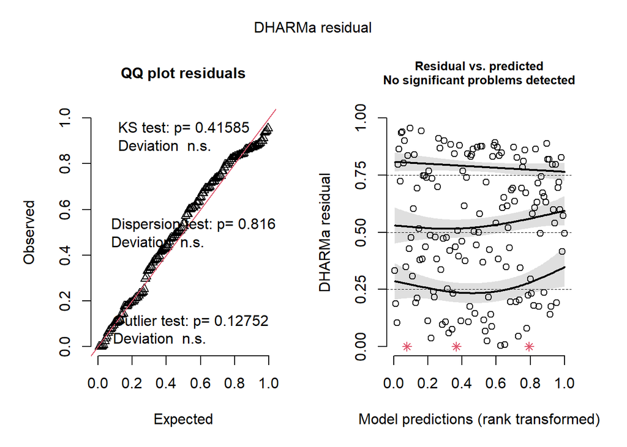

```r
#Diagnosis
res_m1_freezing <- simulateResiduals(m_freezing)
plot(res_m1_freezing)
```

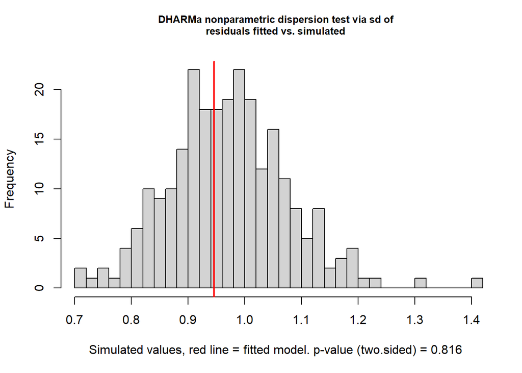

```
##
##  DHARMa nonparametric dispersion test via sd of residuals fitted vs.
##  simulated
##
## data:  simulationOutput
## dispersion = 0.97399, p-value = 0.816
## alternative hypothesis: two.sided
```

```r
testDispersion(res_m1_freezing)
```

```r
testZeroInflation(res_m1_freezing)
```

```
##
##  DHARMa zero-inflation test via comparison to expected zeros with
##  simulation under H0 = fitted model
##
## data:  simulationOutput
## ratioObsSim = NaN, p-value = 1
## alternative hypothesis: two.sided
```

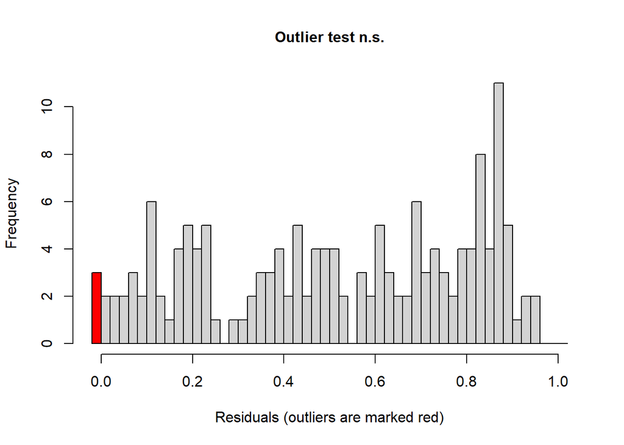

```
##
##  DHARMa outlier test based on exact binomial test with approximate
##  expectations
##
## data:  res_m1_freezing
## outliers at both margin(s) = 3, observations = 155, p-value = 0.1275
## alternative hypothesis: true probability of success is not equal to 0.007968127
## 95 percent confidence interval:
##  0.004009358 0.055519235
## sample estimates:
## frequency of outliers (expected: 0.00796812749003984 )
##                                             0.01935484
```

```r
testOutliers(res_m1_freezing)
```

```r
#Anova
Anova(m_freezing, type = "II")
```

```
## Anova Table (Type II tests)
##
## Response: freezing_s
##               Sum Sq  Df F value Pr(>F)
## treatment     133299   2  1.6603 0.1936
## sex            49142   1  1.2241 0.2703
## body_mass_sc   14062   1  0.3503 0.5548
## Residuals    6021609 150
```

```r
emmeans(m_freezing, pairwise ~ treatment, adjust = "tukey")
```

```
## $emmeans
##  treatment emmean   SE  df lower.CL upper.CL
##  control      978 27.8 150      923     1033
##  low          949 27.8 150      895     1004
##  high         907 28.1 150      851      962
##
## Results are averaged over the levels of: sex
## Confidence level used: 0.95
##
## $contrasts
##  contrast       estimate   SE  df t.ratio p.value
##  control - low      28.7 39.3 150   0.730  0.7460
##  control - high     71.6 39.5 150   1.812  0.1692
##  low - high         42.9 39.6 150   1.083  0.5259
##
## Results are averaged over the levels of: sex
## P value adjustment: tukey method for comparing a family of 3 estimates
```

## Plotting

## Behaviour: Time_freezing

```r
#---------------------------------------------------------
# Estimated marginal means
#---------------------------------------------------------

emm_freezing_df <- as.data.frame(
  emmeans(m_freezing, ~ treatment)
)

print(emm_freezing_df)
```

```
##  treatment   emmean       SE  df lower.CL  upper.CL
##  control   978.2050 27.79268 150 923.2893 1033.1207
##  low       949.4962 27.80517 150 894.5559 1004.4366
##  high      906.6312 28.10327 150 851.1018  962.1606
##
## Results are averaged over the levels of: sex
## Confidence level used: 0.95
```

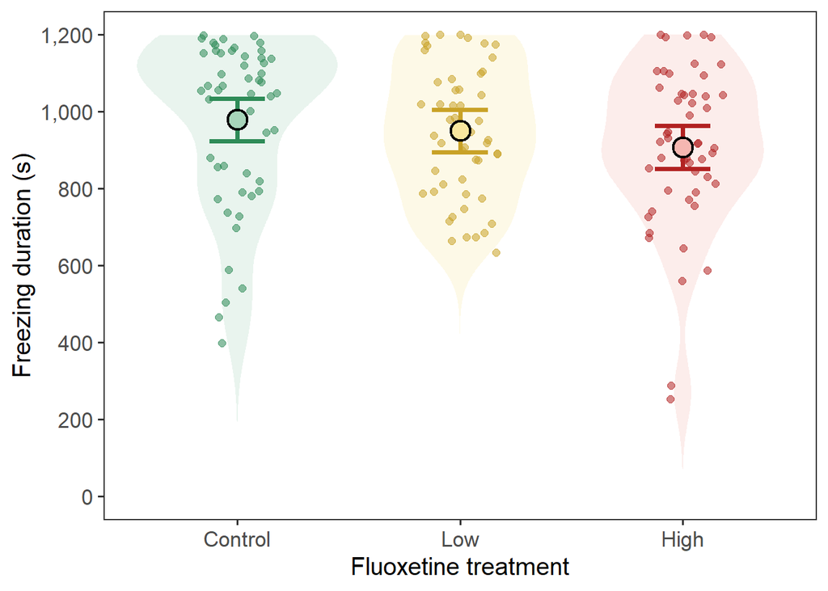

```r
#---------------------------------------------------------
# Standardise column names
#---------------------------------------------------------

cn <- names(emm_freezing_df)

mean_col  <- dplyr::first(cn[cn %in% c("response", "rate", "emmean")])

lower_col <- dplyr::first(
  cn[grepl("^lower\\.CL$|^asymp\\.LCL$|^LCL$|^lower$", cn)]
)

upper_col <- dplyr::first(
  cn[grepl("^upper\\.CL$|^asymp\\.UCL$|^UCL$|^upper$", cn)]
)

if (is.na(mean_col) | is.na(lower_col) | is.na(upper_col)) {
  stop("Could not identify CI columns.")
}

emm_freezing_df <- emm_freezing_df %>%
  mutate(
    treatment = factor(
      treatment,
      levels = c("control", "low", "high")
    ),
    treatment_plot = factor(
      treatment,
      levels = c("control", "low", "high"),
      labels = c("Control", "Low", "High")
    )
  ) %>%
  rename(
    mean  = !!mean_col,
    lower = !!lower_col,
    upper = !!upper_col
  )

#---------------------------------------------------------
# Colour palettes
#---------------------------------------------------------

pastel_cols <- c(
  "Control" = "#A8D5BA",
  "Low"     = "#F9E79F",
  "High"    = "#F5B7B1"
)

dark_cols <- c(
  "Control" = "#2E8B57",
  "Low"     = "#C9A227",
  "High"    = "#B22222"
)

#---------------------------------------------------------
# Plot
#---------------------------------------------------------

p_freezing <- ggplot() +

  geom_violin(
    data = data,
    aes(
      x = treatment_plot,
      y = freezing_s,
      fill = treatment_plot
    ),
    trim = FALSE,
    alpha = 0.25,
    colour = NA,
    linewidth = 0
  ) +

  geom_jitter(
    data = data,
    aes(
      x = treatment_plot,
      y = freezing_s,
      colour = treatment_plot
    ),
    width = 0.18,
    alpha = 0.55,
    size = 2
  ) +

  geom_errorbar(
    data = emm_freezing_df,
    aes(
      x = treatment_plot,
      ymin = lower,
      ymax = upper,
      colour = treatment_plot
    ),
    width = 0.25,
    linewidth = 1.3
  ) +

  geom_point(
    data = emm_freezing_df,
    aes(
      x = treatment_plot,
      y = mean,
      fill = treatment_plot
    ),
    shape = 21,
    size = 5,
    stroke = 1.2,
    colour = "black"
  ) +

  scale_colour_manual(values = dark_cols) +
  scale_fill_manual(values = pastel_cols) +

  scale_y_continuous(
    limits = c(0, 1200),
    breaks = seq(0, 1200, by = 200),
    labels = scales::comma
  ) +

  labs(
    x = "Fluoxetine treatment",
    y = "Freezing duration (s)"
  ) +

  theme_bw(base_size = 14) +

  theme(
    panel.grid = element_blank(),
    legend.position = "none",
    plot.title = element_blank(),
    axis.title = element_text(size = 15),
    axis.text = element_text(size = 13)
  )

print(p_freezing)
```

```r
#---------------------------------------------------------
# Save
#---------------------------------------------------------

ggsave( filename = here("figures", "freezing_duration.pdf"), plot = p_freezing, width = 6, height = 5)
ggsave(filename = here("figures", "freezing_duration.jpg"), plot = p_freezing, width = 6, height = 5, dpi = 600)
```

## Refuge duration x sex

## Refuge_duration: time that fish spend under the shelter during the trials.Refuge duration exhibited a zero-inflated continuous distribution, with approximately 13% of fish never entering the refuge (0 s). To appropriately model this response, a Tweedie GLM was fitted because the Tweedie distribution accommodates continuous positive values while allowing an exact mass at zero, making it well suited for ecological time-to-event and duration data with excess zeros.

```r
# Model: family Tweedie
m_refuge_int <- glmmTMB(
  refuge_duration_s ~ treatment * sex + body_mass_sc +
    (1 | tank_id),
  family = tweedie(link = "log"),
  data = data
)

summary(m_refuge_int)
```

```
##  Family: tweedie  ( log )
## Formula:
## refuge_duration_s ~ treatment * sex + body_mass_sc + (1 | tank_id)
## Data: data
##
##      AIC      BIC   logLik deviance df.resid
##   2016.6   2047.0   -998.3   1996.6      145
##
## Random effects:
##
## Conditional model:
##  Groups  Name        Variance  Std.Dev.
##  tank_id (Intercept) 4.213e-09 6.491e-05
## Number of obs: 155, groups:  tank_id, 24
##
## Dispersion parameter for tweedie family (): 13.9
##
## Conditional model:
##                       Estimate Std. Error z value Pr(>|z|)
## (Intercept)            5.69972    0.21249  26.823   <2e-16 ***
## treatmentlow          -0.07596    0.29522  -0.257   0.7970
## treatmenthigh          0.19502    0.29242   0.667   0.5048
## sexmale                0.49696    0.28542   1.741   0.0817 .
## body_mass_sc          -0.08629    0.08601  -1.003   0.3157
## treatmentlow:sexmale  -0.07783    0.39695  -0.196   0.8445
## treatmenthigh:sexmale -0.73002    0.40142  -1.819   0.0690 .
## ---
## Signif. codes:  0 '***' 0.001 '**' 0.01 '*' 0.05 '.' 0.1 ' ' 1
```

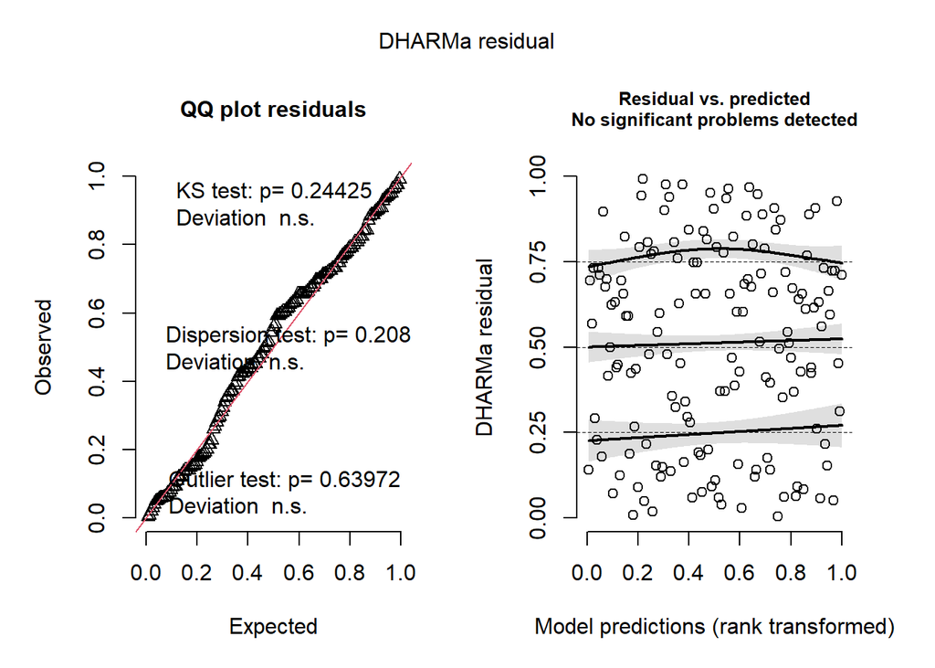

```r
# Diagnosis

simulationOutput <- simulateResiduals(m_refuge_int)
plot(simulationOutput)
```

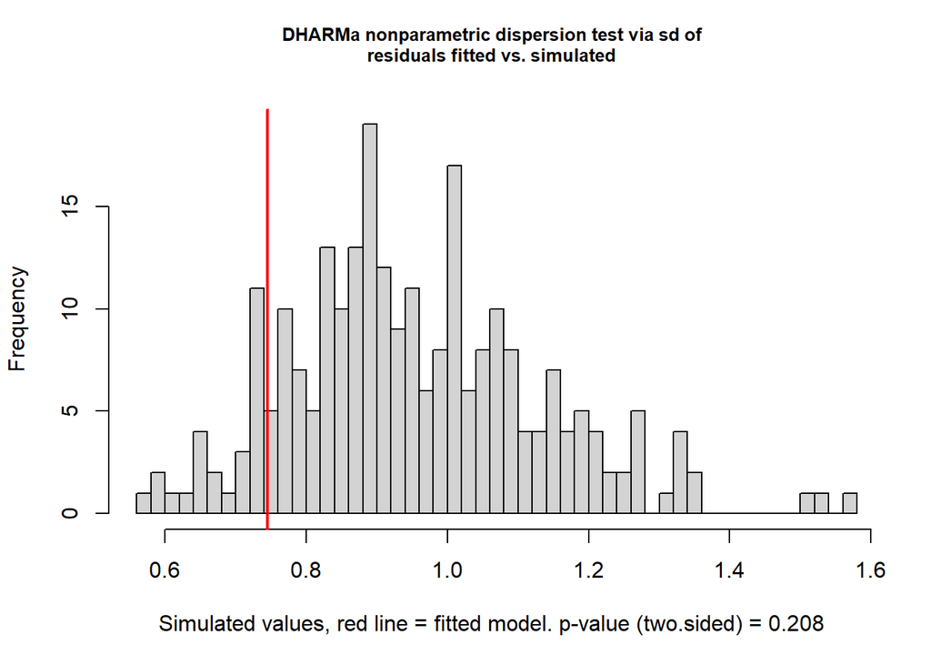

```
##
##  DHARMa nonparametric dispersion test via sd of residuals fitted vs.
##  simulated
##
## data:  simulationOutput
## dispersion = 0.77975, p-value = 0.208
## alternative hypothesis: two.sided
```

```r
testDispersion(simulationOutput)
```

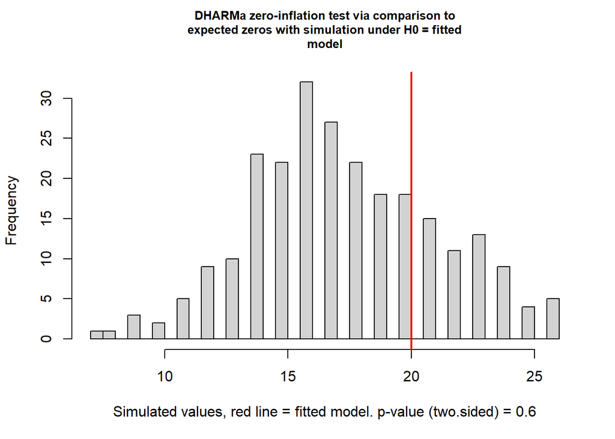

```
##
##  DHARMa zero-inflation test via comparison to expected zeros with
##  simulation under H0 = fitted model
##
## data:  simulationOutput
## ratioObsSim = 1.1421, p-value = 0.6
## alternative hypothesis: two.sided
```

```r
testZeroInflation(simulationOutput)
```

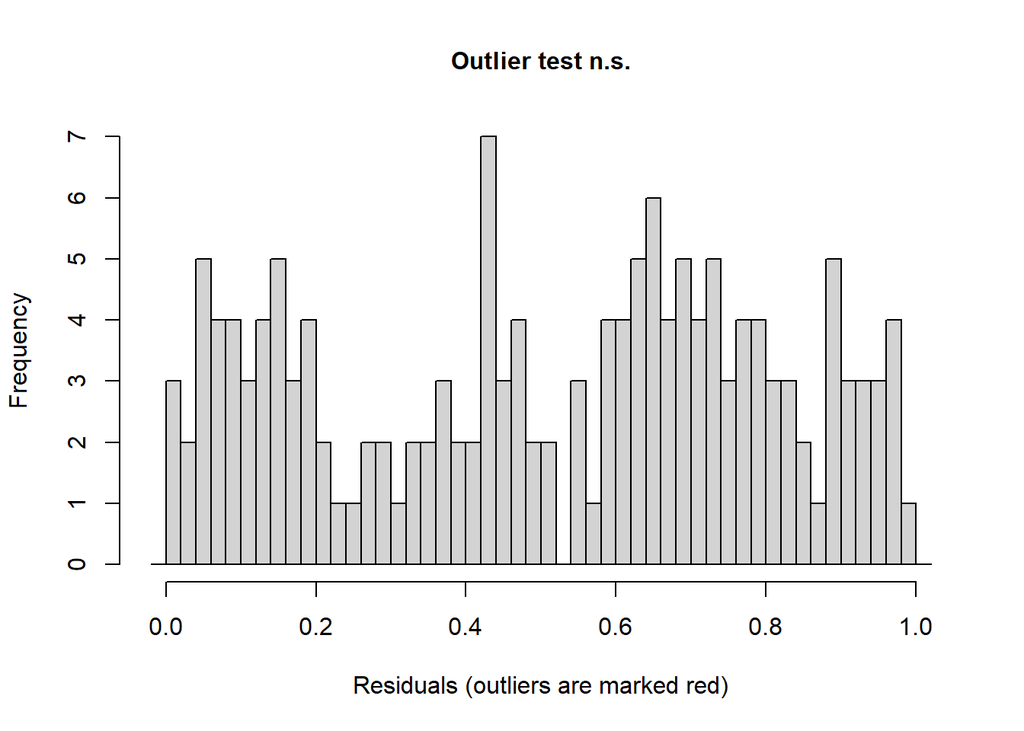

```
##
##  DHARMa outlier test based on exact binomial test with approximate
##  expectations
##
## data:  simulationOutput
## outliers at both margin(s) = 0, observations = 155, p-value = 0.6397
## alternative hypothesis: true probability of success is not equal to 0.007968127
## 95 percent confidence interval:
##  0.00000000 0.02351825
## sample estimates:
## frequency of outliers (expected: 0.00796812749003984 )
##                                                      0
```

```r
testOutliers(simulationOutput)
```

```r
#Anova of the model
Anova(m_refuge_int, type = "III")
```

```
## Analysis of Deviance Table (Type III Wald chisquare tests)
##
## Response: refuge_duration_s
##                  Chisq Df Pr(>Chisq)
## (Intercept)   719.4962  1    < 2e-16 ***
## treatment       0.9203  2    0.63119
## sex             3.0316  1    0.08166 .
## body_mass_sc    1.0065  1    0.31574
## treatment:sex   3.9046  2    0.14194
## ---
## Signif. codes:  0 '***' 0.001 '**' 0.01 '*' 0.05 '.' 0.1 ' ' 1
```

```r
emm_refuge_int <- emmeans(
    m_refuge_int,
    ~ treatment | sex,
    type = "response"
)

pairs(
    emm_refuge_int,
    adjust = "tukey"
)
```

```
## sex = female:
##  contrast       ratio    SE  df null z.ratio p.value
##  control / low  1.079 0.319 Inf    1   0.257  0.9642
##  control / high 0.823 0.241 Inf    1  -0.667  0.7827
##  low / high     0.763 0.223 Inf    1  -0.928  0.6226
##
## sex = male:
##  contrast       ratio    SE  df null z.ratio p.value
##  control / low  1.166 0.310 Inf    1   0.579  0.8312
##  control / high 1.707 0.469 Inf    1   1.948  0.1254
##  low / high     1.464 0.414 Inf    1   1.347  0.3691
##
## P value adjustment: tukey method for comparing a family of 3 estimates
## Tests are performed on the log scale
```

```r
emmeans(
    m_refuge_int,
    pairwise ~ sex | treatment,
    type = "response",
    adjust = "tukey"
)
```

```
## $emmeans
## treatment = control:
##  sex    response   SE  df asymp.LCL asymp.UCL
##  female      299 63.5 Inf       197       453
##  male        491 90.7 Inf       342       705
##
## treatment = low:
##  sex    response   SE  df asymp.LCL asymp.UCL
##  female      277 58.6 Inf       183       419
##  male        421 83.1 Inf       286       620
##
## treatment = high:
##  sex    response   SE  df asymp.LCL asymp.UCL
##  female      363 75.2 Inf       242       545
##  male        288 58.9 Inf       193       430
##
## Confidence level used: 0.95
## Intervals are back-transformed from the log scale
##
## $contrasts
## treatment = control:
##  contrast      ratio    SE  df null z.ratio p.value
##  female / male 0.608 0.174 Inf    1  -1.741  0.0817
##
## treatment = low:
##  contrast      ratio    SE  df null z.ratio p.value
##  female / male 0.658 0.194 Inf    1  -1.422  0.1550
##
## treatment = high:
##  contrast      ratio    SE  df null z.ratio p.value
##  female / male 1.262 0.369 Inf    1   0.798  0.4251
##
## Tests are performed on the log scale
```

#Plotting refuge_duration * sex

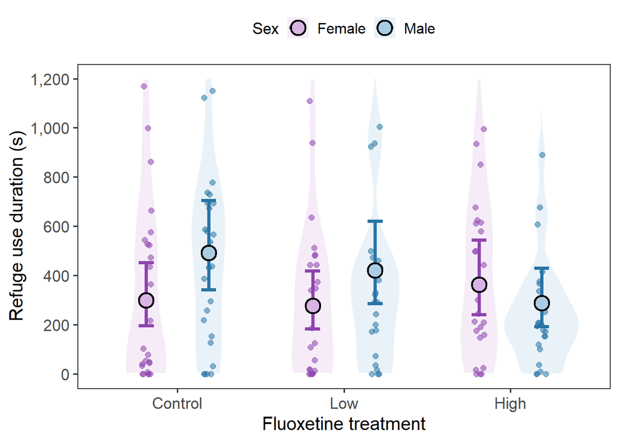

```r
#---------------------------------------------------------
# Prepare labels
#---------------------------------------------------------

data <- data %>%
  mutate(
    treatment = factor(treatment, levels = c("control", "low", "high")),
    sex = factor(sex, levels = c("female", "male")),
    treatment_plot = factor(
      treatment,
      levels = c("control", "low", "high"),
      labels = c("Control", "Low", "High")
    ),
    sex_plot = factor(
      sex,
      levels = c("female", "male"),
      labels = c("Female", "Male")
    )
  )

#---------------------------------------------------------
# Estimated marginal means for treatment × sex interaction
# response scale because model uses Tweedie with log link
#---------------------------------------------------------

emm_refuge_int_df <- as.data.frame(
  emmeans(
    m_refuge_int,
    ~ sex | treatment,
    type = "response"
  )
)

cn <- names(emm_refuge_int_df)

mean_col  <- dplyr::first(cn[cn %in% c("response", "rate", "emmean")])

lower_col <- dplyr::first(
  cn[grepl("^lower\\.CL$|^asymp\\.LCL$|^LCL$|^lower$", cn)]
)

upper_col <- dplyr::first(
  cn[grepl("^upper\\.CL$|^asymp\\.UCL$|^UCL$|^upper$", cn)]
)

emm_refuge_int_df <- emm_refuge_int_df %>%
  mutate(
    treatment = factor(treatment, levels = c("control", "low", "high")),
    sex = factor(sex, levels = c("female", "male")),
    treatment_plot = factor(
      treatment,
      levels = c("control", "low", "high"),
      labels = c("Control", "Low", "High")
    ),
    sex_plot = factor(
      sex,
      levels = c("female", "male"),
      labels = c("Female", "Male")
    )
  ) %>%
  rename(
    mean  = !!mean_col,
    lower = !!lower_col,
    upper = !!upper_col
  )

#---------------------------------------------------------
# Colour palettes for sex
#---------------------------------------------------------

sex_pastel_cols <- c(
  "Female" = "#D8B4E2",
  "Male"   = "#A9CCE3"
)

sex_dark_cols <- c(
  "Female" = "#8E44AD",
  "Male"   = "#2874A6"
)

#---------------------------------------------------------
# Plot: sex side by side within treatment
#---------------------------------------------------------

pd <- position_dodge(width = 0.75)

pj <- position_jitterdodge(
  jitter.width = 0.12,
  dodge.width = 0.75
)

p_refuge_int_side <- ggplot() +

  geom_violin(
    data = data,
    aes(
      x = treatment_plot,
      y = refuge_duration_s,
      fill = sex_plot,
      group = interaction(treatment_plot, sex_plot)
    ),
    position = pd,
    trim = FALSE,
    alpha = 0.25,
    colour = NA,
    linewidth = 0
  ) +

  geom_point(
    data = data,
    aes(
      x = treatment_plot,
      y = refuge_duration_s,
      colour = sex_plot,
      group = sex_plot
    ),
    position = pj,
    alpha = 0.55,
    size = 2
  ) +

  geom_errorbar(
    data = emm_refuge_int_df,
    aes(
      x = treatment_plot,
      ymin = lower,
      ymax = upper,
      colour = sex_plot,
      group = sex_plot
    ),
    position = pd,
    width = 0.18,
    linewidth = 1.3
  ) +

  geom_point(
    data = emm_refuge_int_df,
    aes(
      x = treatment_plot,
      y = mean,
      fill = sex_plot,
      group = sex_plot
    ),
    position = pd,
    shape = 21,
    size = 5,
    stroke = 1.2,
    colour = "black"
  ) +

  scale_colour_manual(values = sex_dark_cols) +
  scale_fill_manual(values = sex_pastel_cols) +

  scale_y_continuous(
    limits = c(0, 1200),
    breaks = seq(0, 1200, by = 200),
    labels = scales::comma
  ) +

  labs(
    x = "Fluoxetine treatment",
    y = "Refuge use duration (s)",
    fill = "Sex",
    colour = "Sex"
  ) +

  theme_bw(base_size = 14) +

  theme(
    panel.grid = element_blank(),
    legend.position = "top",
    legend.title = element_text(size = 13),
    legend.text = element_text(size = 12),
    axis.title = element_text(size = 15),
    axis.text = element_text(size = 13)
  )

print(p_refuge_int_side)
```

```r
#---------------------------------------------------------
# Save
#---------------------------------------------------------

ggsave(
  filename = here("figures", "refuge_treatment_sex_side_by_side.pdf"),
  plot = p_refuge_int_side,
  width = 7,
  height = 5
)
ggsave(
  filename = here("figures", "refuge_treatment_sex_side_by_side.jpg"),
  plot = p_refuge_int_side,
  width = 7,
  height = 5,
  dpi = 600
)
```

# Refuge_duration: main effects model

```r
#Model: family Tweedie
m_refuge <- glmmTMB(
    refuge_duration_s ~ treatment + sex + body_mass_sc +
    (1 | tank_id),
    family = tweedie(link = "log"),
    data = data
)

summary(m_refuge)
```

```
##  Family: tweedie  ( log )
## Formula:
## refuge_duration_s ~ treatment + sex + body_mass_sc + (1 | tank_id)
## Data: data
##
##      AIC      BIC   logLik deviance df.resid
##   2016.4   2040.8  -1000.2   2000.4      147
##
## Random effects:
##
## Conditional model:
##  Groups  Name        Variance  Std.Dev.
##  tank_id (Intercept) 3.627e-09 6.023e-05
## Number of obs: 155, groups:  tank_id, 24
##
## Dispersion parameter for tweedie family (): 13.8
##
## Conditional model:
##               Estimate Std. Error z value Pr(>|z|)
## (Intercept)    5.85407    0.17194   34.05   <2e-16 ***
## treatmentlow  -0.12718    0.19951   -0.64    0.524
## treatmenthigh -0.18395    0.20193   -0.91    0.362
## sexmale        0.22669    0.17711    1.28    0.201
## body_mass_sc  -0.07212    0.08625   -0.84    0.403
## ---
## Signif. codes:  0 '***' 0.001 '**' 0.01 '*' 0.05 '.' 0.1 ' ' 1
```

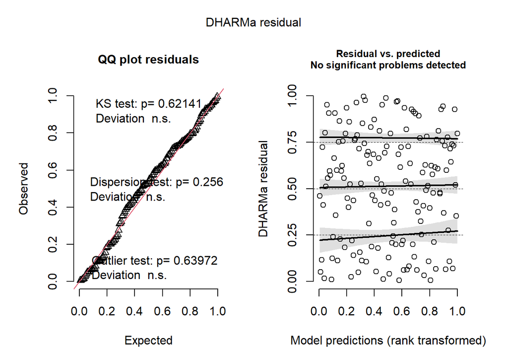

```r
# Diagnosis

simulationOutput <- simulateResiduals(m_refuge)
plot(simulationOutput)
```

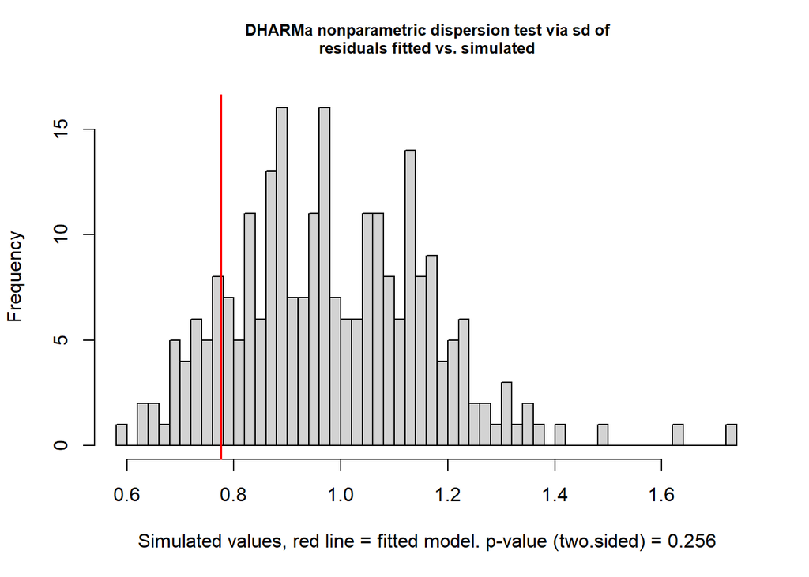

```
##
##  DHARMa nonparametric dispersion test via sd of residuals fitted vs.
##  simulated
##
## data:  simulationOutput
## dispersion = 0.7886, p-value = 0.256
## alternative hypothesis: two.sided
```

```r
testDispersion(simulationOutput)
```

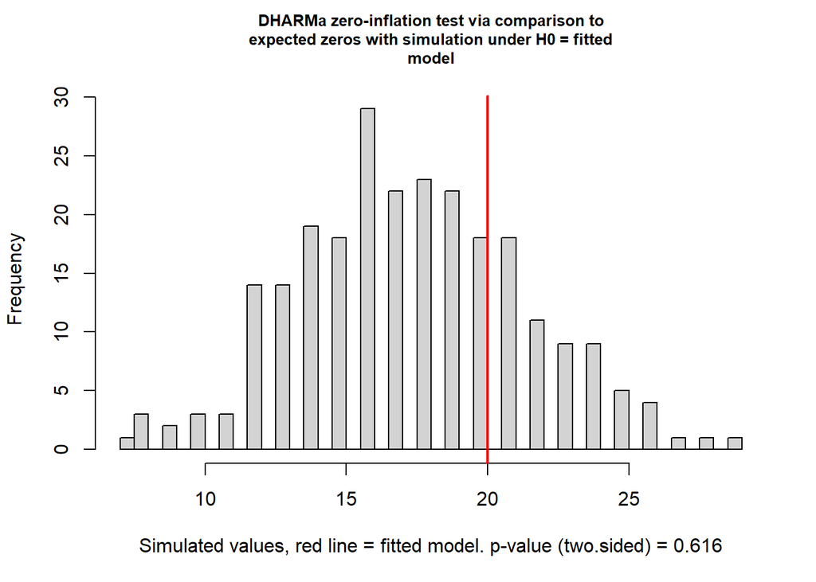

```
##
##  DHARMa zero-inflation test via comparison to expected zeros with
##  simulation under H0 = fitted model
##
## data:  simulationOutput
## ratioObsSim = 1.1405, p-value = 0.616
## alternative hypothesis: two.sided
```

```r
testZeroInflation(simulationOutput)
```

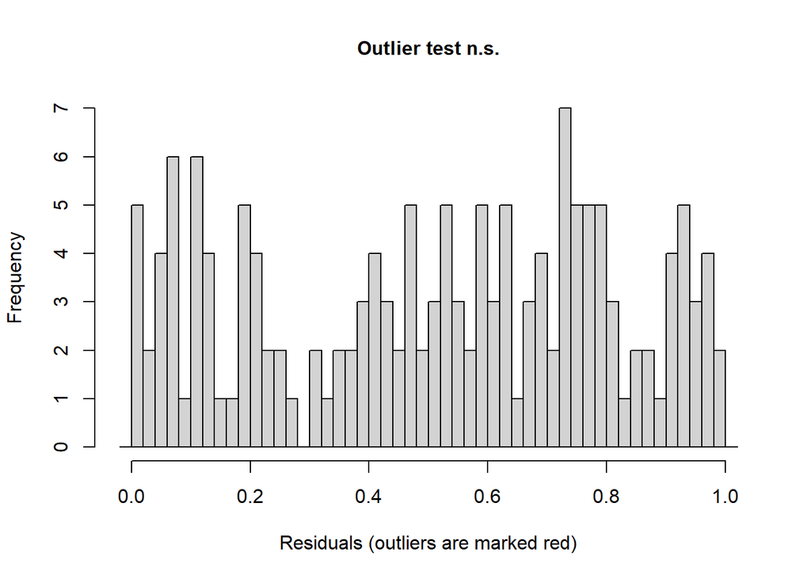

```
##
##  DHARMa outlier test based on exact binomial test with approximate
##  expectations
##
## data:  simulationOutput
## outliers at both margin(s) = 0, observations = 155, p-value = 0.6397
## alternative hypothesis: true probability of success is not equal to 0.007968127
## 95 percent confidence interval:
##  0.00000000 0.02351825
## sample estimates:
## frequency of outliers (expected: 0.00796812749003984 )
##                                                      0
```

```r
testOutliers(simulationOutput)
```

```r
#Anova of the model
Anova(m_refuge, type = "II")
```

```
## Analysis of Deviance Table (Type II Wald chisquare tests)
##
## Response: refuge_duration_s
##               Chisq Df Pr(>Chisq)
## treatment    0.8827  2     0.6432
## sex          1.6382  1     0.2006
## body_mass_sc 0.6992  1     0.4030
```

```r
emm_refuge <- emmeans(
    m_refuge,
    ~ treatment,
    type = "response"
)

emm_refuge
```

```
##  treatment response   SE  df asymp.LCL asymp.UCL
##  control        391 54.4 Inf       297       513
##  low            344 49.3 Inf       260       455
##  high           325 47.5 Inf       244       433
##
## Results are averaged over the levels of: sex
## Confidence level used: 0.95
## Intervals are back-transformed from the log scale
```

```r
pairs(emm_refuge, adjust = "tukey")
```

```
##  contrast       ratio    SE  df null z.ratio p.value
##  control / low   1.14 0.227 Inf    1   0.637  0.7995
##  control / high  1.20 0.243 Inf    1   0.911  0.6334
##  low / high      1.06 0.217 Inf    1   0.277  0.9586
##
## Results are averaged over the levels of: sex
## P value adjustment: tukey method for comparing a family of 3 estimates
## Tests are performed on the log scale
```

## Plotting

## Behaviour: refuge_duration

```r
#---------------------------------------------------------
# Estimated marginal means (response scale)
#---------------------------------------------------------

emm_refuge_df <- as.data.frame(
  emmeans(
    m_refuge,
    ~ treatment,
    type = "response"
  )
)

print(emm_refuge_df)
```

```
##  treatment response       SE  df asymp.LCL asymp.UCL
##  control   390.5516 54.43418 Inf  297.1939  513.2358
##  low       343.9114 49.27127 Inf  259.7151  455.4031
##  high      324.9302 47.51817 Inf  243.9548  432.7836
##
## Results are averaged over the levels of: sex
## Confidence level used: 0.95
## Intervals are back-transformed from the log scale
```

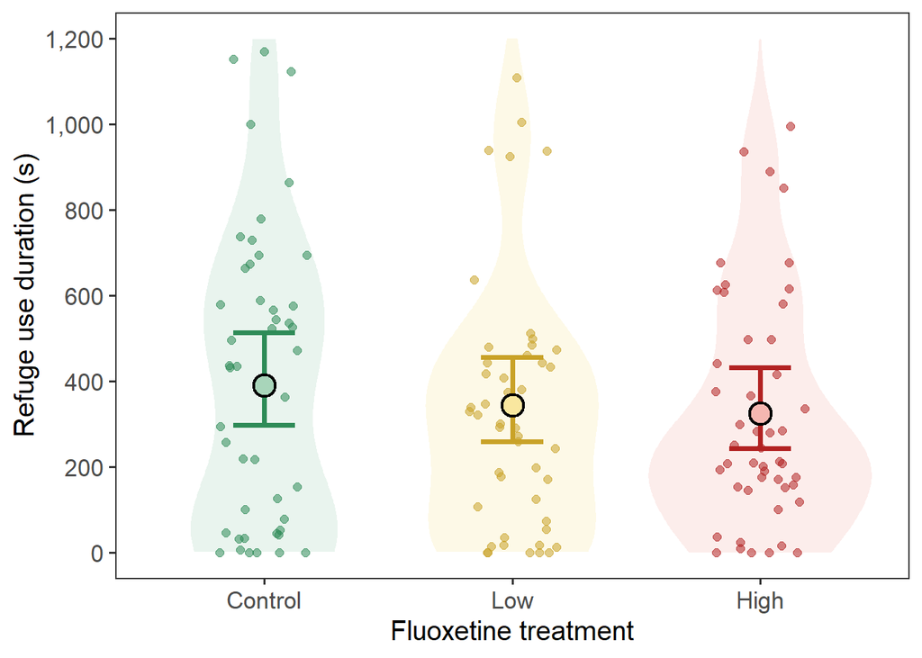

```r
#---------------------------------------------------------
# Standardise column names
#---------------------------------------------------------

cn <- names(emm_refuge_df)

mean_col  <- dplyr::first(cn[cn %in% c("response", "rate", "emmean")])

lower_col <- dplyr::first(
  cn[grepl("^lower\\.CL$|^asymp\\.LCL$|^LCL$|^lower$", cn)]
)

upper_col <- dplyr::first(
  cn[grepl("^upper\\.CL$|^asymp\\.UCL$|^UCL$|^upper$", cn)]
)

emm_refuge_df <- emm_refuge_df %>%
  mutate(
    treatment = factor(
      treatment,
      levels = c("control", "low", "high")
    ),
    treatment_plot = factor(
      treatment,
      levels = c("control", "low", "high"),
      labels = c("Control", "Low", "High")
    )
  ) %>%
  rename(
    mean  = !!mean_col,
    lower = !!lower_col,
    upper = !!upper_col
  )

#---------------------------------------------------------
# Colour palettes
#---------------------------------------------------------

pastel_cols <- c(
  "Control" = "#A8D5BA",
  "Low"     = "#F9E79F",
  "High"    = "#F5B7B1"
)

dark_cols <- c(
  "Control" = "#2E8B57",
  "Low"     = "#C9A227",
  "High"    = "#B22222"
)

#---------------------------------------------------------
# Plot
#---------------------------------------------------------

p_refuge <- ggplot() +

  geom_violin(
    data = data,
    aes(
      x = treatment_plot,
      y = refuge_duration_s,
      fill = treatment_plot
    ),
    trim = FALSE,
    alpha = 0.25,
    colour = NA,
    linewidth = 0
  ) +

  geom_jitter(
    data = data,
    aes(
      x = treatment_plot,
      y = refuge_duration_s,
      colour = treatment_plot
    ),
    width = 0.18,
    alpha = 0.55,
    size = 2
  ) +

  geom_errorbar(
    data = emm_refuge_df,
    aes(
      x = treatment_plot,
      ymin = lower,
      ymax = upper,
      colour = treatment_plot
    ),
    width = 0.25,
    linewidth = 1.3
  ) +

  geom_point(
    data = emm_refuge_df,
    aes(
      x = treatment_plot,
      y = mean,
      fill = treatment_plot
    ),
    shape = 21,
    size = 5,
    stroke = 1.2,
    colour = "black"
  ) +

  scale_colour_manual(values = dark_cols) +
  scale_fill_manual(values = pastel_cols) +

  scale_y_continuous(
    limits = c(0, 1200),
    breaks = seq(0, 1200, by = 200),
    labels = scales::comma
  ) +

  labs(
    x = "Fluoxetine treatment",
    y = "Refuge use duration (s)"
  ) +

  theme_bw(base_size = 14) +

  theme(
    panel.grid = element_blank(),
    legend.position = "none",
    plot.title = element_blank(),
    axis.title = element_text(size = 15),
    axis.text = element_text(size = 13)
  )

print(p_refuge)
```

```r
# Save

ggsave(filename = here("figures", "refuge_duration.pdf"), plot = p_refuge, width = 6, height = 5)
ggsave(filename = here("figures", "refuge_duration.jpg"), plot = p_refuge, width = 6, height = 5, dpi = 600)
```